# Contained Metals

Counting down the mines with the most metal.

Using Mining Intelligences tab on Reserves/Resources: http://data.miningintelligence.com/property/browsesearch.aspx?vt=56

Questions to answer:

-By metal, what mines have the most proven&probable and measured&indicated? -What are the stages of these projects? -Who owns them? -Out of the top ten, what portion of metal do them contain? -What geo region are the metals?

Adding other data.frames for ownership and location.

```r
library(tidyverse)
resraw <- read_csv("C:/Users/Admin/Downloads/resources-report-michael-mccrae-20180409110926 contained metals apr 2018 no ampersand.csv")
```

[output not shown]

```r
resraw
```

| PropertyID | Property | Asof | Resourcesincludereserves | Classification | Tonnage | TonnageUnit | Commodity | Grade | GradeUnits | ContainedMetal | ContainedMetalUnits |
| --- | --- | --- | --- | --- | --- | --- | --- | --- | --- | --- | --- |
| 10007 | 80 Pup | NA | NA | NA | NA | NA | NA | NA | NA | NA | NA |
| 10010 | Abacaxis | NA | NA | NA | NA | NA | NA | NA | NA | NA | NA |
| 10015 | Abcourt-Barvue | May 31 2006 | Yes | Proven and Probable | 6823532 | t | Silver | 57.76 | g/t | 1.267216e+07 | ozt |
| 10015 | Abcourt-Barvue | May 31 2006 | Yes | Proven and Probable | 6823532 | t | Zinc | 3.11 | % | 2.119391e+05 | t |
| 10015 | Abcourt-Barvue | May 31 2006 | Yes | Proven | 6508393 | t | Silver | 55.64 | g/t | 1.164265e+07 | ozt |
| 10015 | Abcourt-Barvue | May 31 2006 | Yes | Proven | 6508393 | t | Zinc | 3.10 | % | 2.017602e+05 | t |
| 10015 | Abcourt-Barvue | May 31 2006 | Yes | Probable | 315139 | t | Silver | 101.61 | g/t | 1.029508e+06 | ozt |
| 10015 | Abcourt-Barvue | May 31 2006 | Yes | Probable | 315139 | t | Zinc | 3.23 | % | 1.017899e+04 | t |
| 10015 | Abcourt-Barvue | May 31 2006 | Yes | Measured and Indicated | 7018969 | t | Silver | 59.81 | g/t | 1.349691e+07 | ozt |
| 10015 | Abcourt-Barvue | May 31 2006 | Yes | Measured and Indicated | 7018969 | t | Zinc | 3.33 | % | 2.336939e+05 | t |

[output cut: 990 more lines]

```r
overviewraw <- read_csv("C:/Users/Admin/Downloads/properties-overview-report-michael-mccrae-20180409140956 overview property.csv")
overviewraw
```

| PropertyID | Property | LastUpdated | WorkType | AssetType | Province | Country | Region | DevelopmentStatus | ActivityStatus | CommodityExposure | X12 |
| --- | --- | --- | --- | --- | --- | --- | --- | --- | --- | --- | --- |
| 10007 | 80 Pup | Apr 12 2013 | Surface | Project | Yukon Territory | Canada | North America | Abandoned | Exploration | Gold | NA |
| 10010 | Abacaxis | Dec 31 1999 | Surface | Project | NA | Brazil | South America | Abandoned | Exploration | Gold | NA |
| 10015 | Abcourt-Barvue | Mar 01 2018 | Open-Pit/Underground | Project | Quebec | Canada | North America | Feasibility | Feasibility | Gold Silver Zinc | NA |
| 10017 | Abior (Malartic Twp) | Apr 12 2013 | Surface | Project | Quebec | Canada | North America | Abandoned | Exploration | Gold | NA |
| 10018 | Abitibi Belt - Guyana Goldfields | Oct 31 1999 | Surface | Project | Ontario | Canada | North America | Abandoned | Prospect | Copper Zinc | NA |
| 10021 | Abuakwa Licence | Jul 26 2005 | Surface | Project | NA | Ghana | Africa | Abandoned | Exploration | Gold | NA |
| 10022 | Abyz | Apr 01 2018 | Open-Pit | Mine | Karaganda | Kazakhstan | Asia | Temporary Suspension | Production | Copper Gold Lead Silver Zinc | NA |
| 10034 | Addington | Feb 28 2007 | Surface | Project | Ontario | Canada | North America | Abandoned | Exploration | Gold | NA |
| 10035 | Adom | Feb 28 2014 | Surface | Project | Western | Ghana | Africa | Abandoned | Prospect | Gold | NA |
| 10039 | Adwoam | Dec 31 1998 | Surface | Project | NA | Ghana | Africa | Abandoned | Prospect | Gold | NA |

[output cut: 990 more lines]

```r
ownershipraw <- read_csv("C:/Users/Admin/Downloads/properties-ownership-report-michael-mccrae-20180409141032 ownership.csv")
ownershipraw
```

| PropertyID | Property | Interest% | CompanyID | Company | X6 |
| --- | --- | --- | --- | --- | --- |
| 10007 | 80 Pup | NA | NA | NA | NA |
| 10010 | Abacaxis | NA | NA | NA | NA |
| 10015 | Abcourt-Barvue | 100.00 | 10076 | Abcourt Mines | NA |
| 10017 | Abior (Malartic Twp) | NA | NA | NA | NA |
| 10018 | Abitibi Belt - Guyana Goldfields | NA | NA | NA | NA |
| 10021 | Abuakwa Licence | NA | NA | NA | NA |
| 10022 | Abyz | 100.00 | 36578 | Cuprum Holding | NA |
| 10034 | Addington | NA | NA | NA | NA |
| 10035 | Adom | NA | NA | NA | NA |
| 10039 | Adwoam | NA | NA | NA | NA |

[output cut: 990 more lines]

Let’s join the data to get ownership and overview

```r
completeraw4 <- resraw %>% semi_join(ownershipraw) %>% semi_join(overviewraw)
completeraw4
```

| PropertyID | Property | Asof | Resourcesincludereserves | Classification | Tonnage | TonnageUnit | Commodity | Grade | GradeUnits | ContainedMetal | ContainedMetalUnits |
| --- | --- | --- | --- | --- | --- | --- | --- | --- | --- | --- | --- |
| 10007 | 80 Pup | NA | NA | NA | NA | NA | NA | NA | NA | NA | NA |
| 10010 | Abacaxis | NA | NA | NA | NA | NA | NA | NA | NA | NA | NA |
| 10015 | Abcourt-Barvue | May 31 2006 | Yes | Proven and Probable | 6823532 | t | Silver | 57.76 | g/t | 1.267216e+07 | ozt |
| 10015 | Abcourt-Barvue | May 31 2006 | Yes | Proven and Probable | 6823532 | t | Zinc | 3.11 | % | 2.119391e+05 | t |
| 10015 | Abcourt-Barvue | May 31 2006 | Yes | Proven | 6508393 | t | Silver | 55.64 | g/t | 1.164265e+07 | ozt |
| 10015 | Abcourt-Barvue | May 31 2006 | Yes | Proven | 6508393 | t | Zinc | 3.10 | % | 2.017602e+05 | t |
| 10015 | Abcourt-Barvue | May 31 2006 | Yes | Probable | 315139 | t | Silver | 101.61 | g/t | 1.029508e+06 | ozt |
| 10015 | Abcourt-Barvue | May 31 2006 | Yes | Probable | 315139 | t | Zinc | 3.23 | % | 1.017899e+04 | t |
| 10015 | Abcourt-Barvue | May 31 2006 | Yes | Measured and Indicated | 7018969 | t | Silver | 59.81 | g/t | 1.349691e+07 | ozt |
| 10015 | Abcourt-Barvue | May 31 2006 | Yes | Measured and Indicated | 7018969 | t | Zinc | 3.33 | % | 2.336939e+05 | t |

[output cut: 990 more lines]

Let’s count.

How many Proven and Probable projects are there by commodities?

```r
countcom <- resraw %>% filter(Classification=="Proven and Probable") %>% count(Commodity) %>% arrange(desc(n))
countcom
```

| Commodity | n |
| --- | --- |
| Gold | 1164 |
| Copper | 542 |
| Silver | 517 |
| Zinc | 237 |
| Steam Coal | 211 |
| Iron - Total | 207 |
| Lead | 180 |
| Raw Steam Coal | 179 |
| Nickel | 117 |
| Raw Coal | 94 |

[output cut: 139 more lines]

What is the total Contained Metal Proven and Probable by commodities?

Use ContainedMetalUnits filter to get gold, base metal and other.

```r
totalcom <- resraw %>% filter(Classification=="Proven and Probable") %>% filter(ContainedMetalUnits=="t") %>% group_by(Commodity) %>% summarise(TotalCommodity=sum(ContainedMetal)) %>% arrange(desc(TotalCommodity))
totalcom
```

| Commodity | TotalCommodity |
| --- | --- |
| Iron - Total | 3.836580e+10 |
| Hematite | 1.656781e+10 |
| Magnetite | 2.683004e+09 |
| Ilmenite | 1.994797e+09 |
| Potash | 1.377805e+09 |
| Aluminum Trioxide - Available | 1.177872e+09 |
| Phosphate | 8.933276e+08 |
| Potassium Oxide | 8.458619e+08 |
| Aluminum Trioxide - Total | 6.722885e+08 |
| Copper | 6.645502e+08 |

[output cut: 70 more lines]

Let’s get the top 10 properties by commodity group for just Proven and Probable and precious.

```r
prove20 <- resraw %>% filter(Classification=="Proven and Probable") %>% filter(ContainedMetalUnits=="ozt") %>% select(Property, Commodity, ContainedMetal) %>% group_by(Commodity) %>% top_n(10, ContainedMetal)
View(prove20)
```

Let’s chart

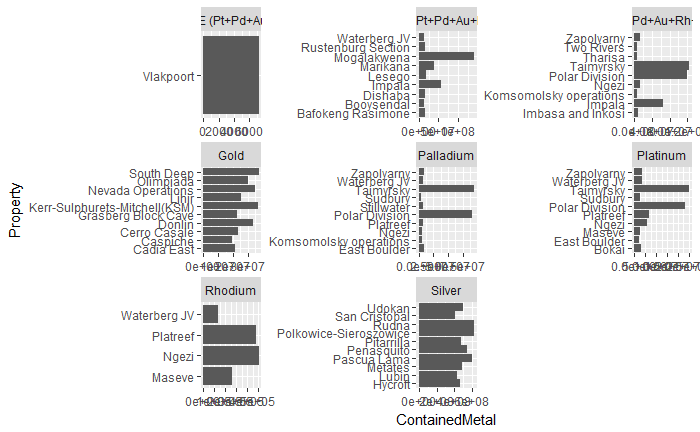

```r
ggplot(prove20, aes(x=Property, y=ContainedMetal)) +
  geom_bar(stat="identity") +
  coord_flip()+
  facet_wrap(~Commodity, scales="free")
```

I would like to order facets by descending order. I will use instructions at https://drsimonj.svbtle.com/ordering-categories-within-ggplot2-facets

```r
###ozt for precious
precious10 <- resraw %>% filter(Classification=="Proven and Probable") %>% filter(ContainedMetalUnits=="ozt") %>% select(Property, Commodity, ContainedMetal)  %>% group_by(Commodity) %>% top_n(10, ContainedMetal) %>% ungroup() %>% arrange(Commodity, ContainedMetal) %>% mutate(order=row_number())
precious10
```

| Property | Commodity | ContainedMetal | order |
| --- | --- | --- | --- |
| Vlakpoort | 3E (Pt+Pd+Au) | 7211.71 | 1 |
| Waterberg JV | 4E (Pt+Pd+Au+Rh) | 12316563.46 | 2 |
| Booysendal | 4E (Pt+Pd+Au+Rh) | 12651929.66 | 3 |
| Bafokeng Rasimone | 4E (Pt+Pd+Au+Rh) | 15920731.74 | 4 |
| Rustenburg Section | 4E (Pt+Pd+Au+Rh) | 16130225.76 | 5 |
| Dishaba | 4E (Pt+Pd+Au+Rh) | 16310201.89 | 6 |
| Lesego | 4E (Pt+Pd+Au+Rh) | 18089852.91 | 7 |
| Impala | 4E (Pt+Pd+Au+Rh) | 23276938.44 | 8 |
| Impala | 4E (Pt+Pd+Au+Rh) | 32550828.44 | 9 |
| Marikana | 4E (Pt+Pd+Au+Rh) | 37616377.48 | 10 |

[output cut: 55 more lines]

```r
###t for everything else
base10 <- resraw %>% filter(Classification=="Proven and Probable") %>% filter(ContainedMetalUnits=="t") %>% select(Property, Commodity, ContainedMetal)  %>% group_by(Commodity) %>% top_n(10, ContainedMetal) %>% ungroup() %>% arrange(Commodity, ContainedMetal) %>% mutate(order=row_number())
base10
```

| Property | Commodity | ContainedMetal | order |
| --- | --- | --- | --- |
| Bodai Daldali | Alumina | 1.046400e+06 | 1 |
| Nayega | Aluminum | 1.024770e+06 | 2 |
| Farim | Aluminum | 1.144000e+06 | 3 |
| Mainpat | Aluminum | 2.208300e+06 | 4 |
| St Ann | Aluminum | 7.343536e+06 | 5 |
| Az Zabirah | Aluminum Trioxide - Available | 1.242194e+07 | 6 |
| Juruti | Aluminum Trioxide - Available | 1.615640e+07 | 7 |
| Ayatskoye | Aluminum Trioxide - Available | 1.947067e+07 | 8 |
| Skardon River | Aluminum Trioxide - Available | 1.952880e+07 | 9 |
| Trombetas | Aluminum Trioxide - Available | 2.454100e+07 | 10 |

[output cut: 412 more lines]

Try faceting again with orders. This is precious

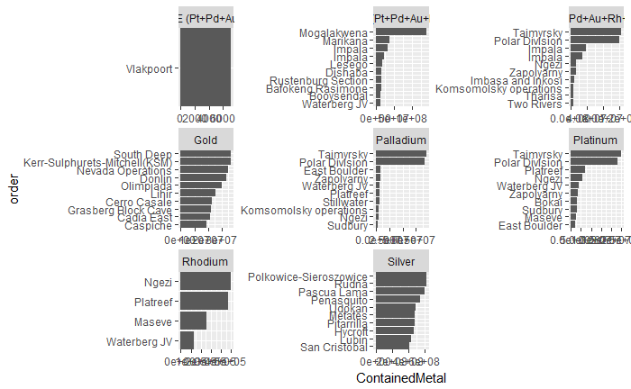

```r
ggplot(precious10, aes(x=order, y=ContainedMetal)) +
  geom_bar(stat="identity") +
  facet_wrap(~Commodity, scales="free") +
# Add categories to axis
  scale_x_continuous(
    breaks = precious10$order,
    labels = precious10$Property,
    expand = c(0,0)
  ) +
  coord_flip()
```

Try faceting again with orders. This is base

[figure not shown]

```r
ggplot(base10, aes(x=order, y=ContainedMetal)) +
  geom_bar(stat="identity") +
  facet_wrap(~Commodity, scales="free") +
# Add categories to axis
  scale_x_continuous(
    breaks = base10$order,
    labels = base10$Property,
    expand = c(0,0)
  ) +
  coord_flip()
```